# PDX: COX2-Stroma pathway

Alistair Martin

Last modified: 06 Nov 2018

#Load libraries and data

```r
root.dir <- "~/OneDrive/projects/"
source(paste0(root.dir,"R.utils/RNASEQ.utils.R"))

project.dir <- paste0(root.dir,"PDX/")
source(paste0(project.dir,"src/load.PDX.R"))
rnaseq <- get.PDX()
meta <- load.meta()

meta <- subset.meta(meta,meta[,project=="characterisation"])
rnaseq <- subset.PDX(rnaseq, rnaseq$meta[,Sample.name] %in% meta[,Sample.name])
rnaseq <- merge.PDX(rnaseq)
rnaseq$meta[,merged.lanes:=as.numeric(as.factor(merged.lanes))]

rnaseq$meta <- merge(rnaseq$meta,meta,sort=F)
rnaseq <- subset.PDX(rnaseq, rnaseq$meta[,sample.type == "xenograft"])
rnaseq <- subset.PDX(rnaseq, rnaseq$meta[,human.library.size > 1e6])
rnaseq <- subset.PDX(rnaseq, rnaseq$meta[,mouse.library.size/(human.library.size+mouse.library.size) < .8])
```

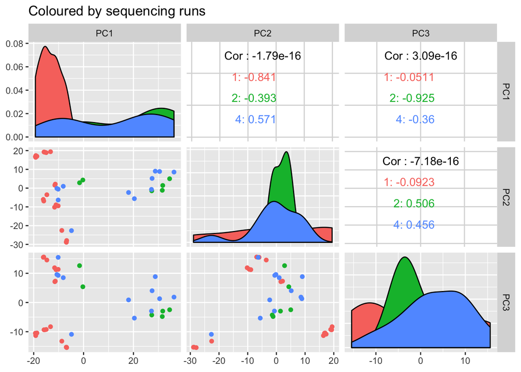

```r
x <-  norm.count.matrix(rnaseq$human)
#x <- removeBatchEffect(x,batch=rnaseq$meta$merged.lanes)
i <- which(rownames(x) == "ENSG00000073756")
COX2.human.exp <- x[i,]
pca.human <- pca.run(x,normalise = F)


ggpairs(cbind(pca.human,rnaseq$meta,COX2.human.exp),columns = 1:3,mapping = aes(color=factor(merged.lanes)),title="Coloured by sequencing runs")
```

[output not shown]

[output cut: 10 more lines]

[output not shown]

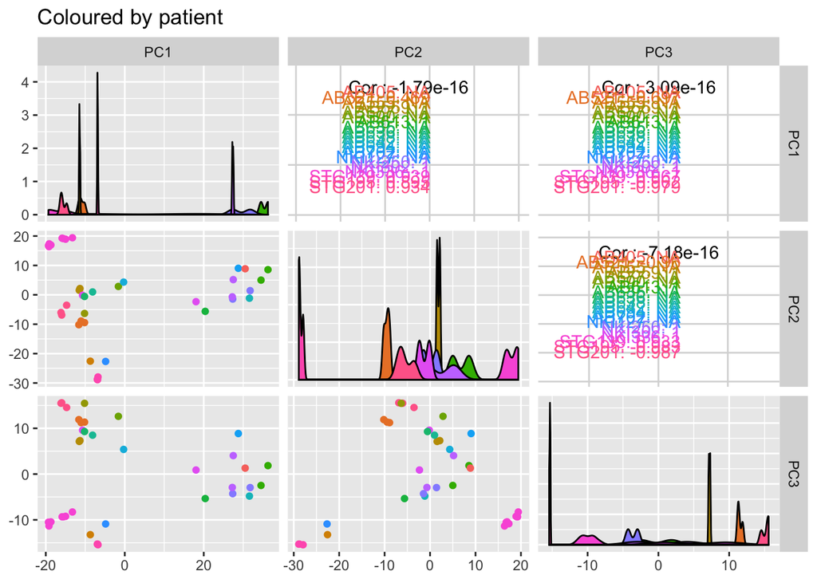

```r
ggpairs(cbind(pca.human,rnaseq$meta,COX2.human.exp),columns = 1:3,mapping = aes(color=factor(patient)),title="Coloured by patient")
```

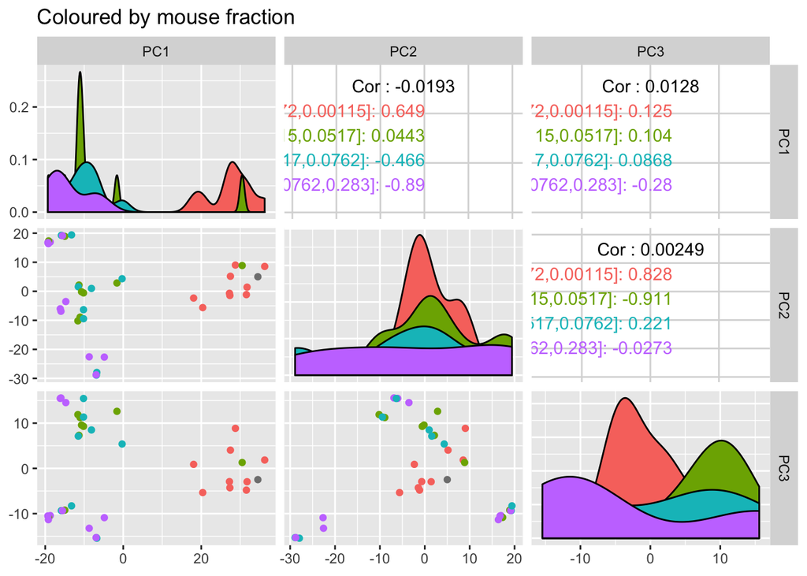

```r
ggpairs(cbind(pca.human,rnaseq$meta,COX2.human.exp),columns = 1:3,mapping = aes(color=cut(mouse.library.size/(human.library.size+mouse.library.size),quantile(mouse.library.size/(human.library.size+mouse.library.size)))),title="Coloured by mouse fraction")
```

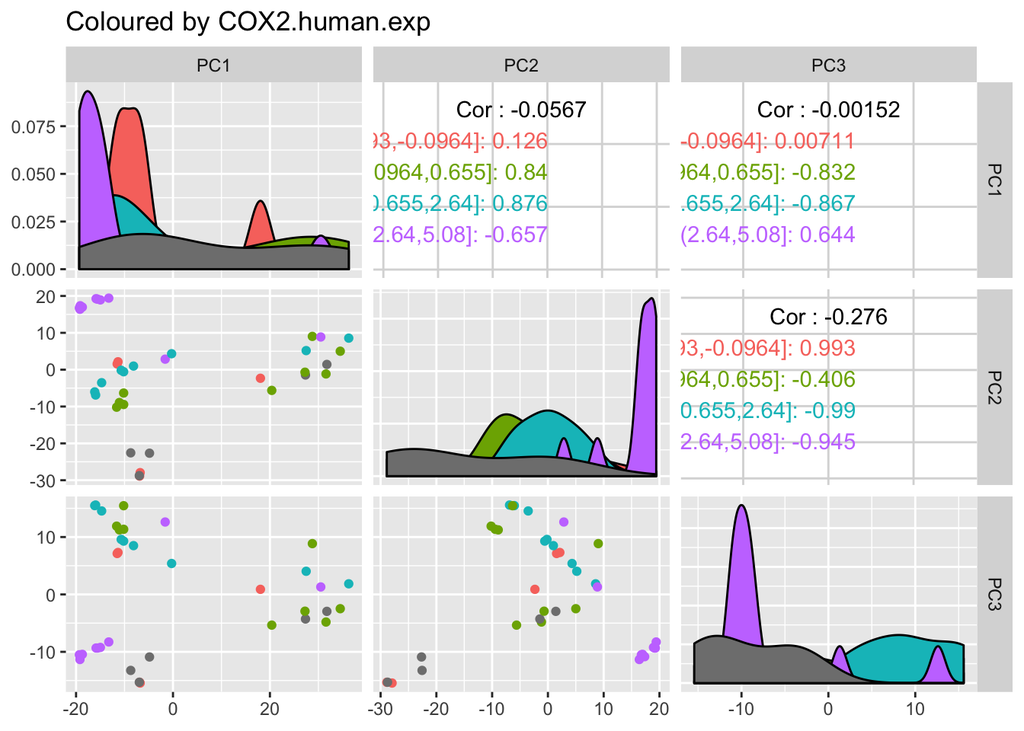

```r
ggpairs(cbind(pca.human,rnaseq$meta,COX2.human.exp),columns = 1:3,mapping = aes(color=cut(COX2.human.exp,quantile(COX2.human.exp))),title="Coloured by COX2.human.exp")
```

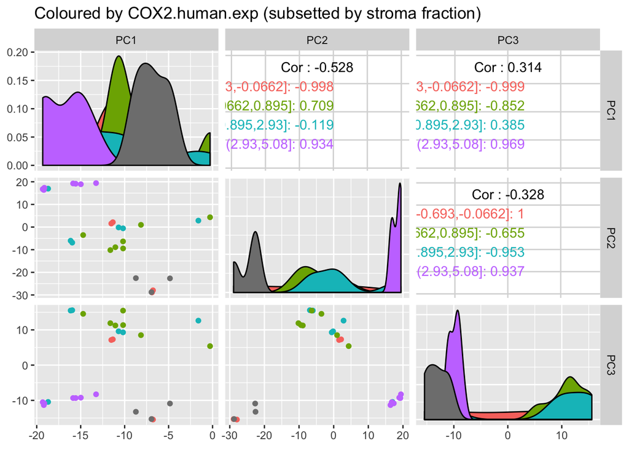

```r
ggpairs(cbind(pca.human,rnaseq$meta,COX2.human.exp)[mouse.library.size/(human.library.size+mouse.library.size)>0.01],columns = 1:3,mapping = aes(color=cut(COX2.human.exp,quantile(COX2.human.exp))),title="Coloured by COX2.human.exp (subsetted by stroma fraction)")
```

# COX2 Signatures w.r.t human reads

```r
PoI <- list(
  "COX2_UP_UP" = "IL6 IL1B IL1A CXCL1 CXCL2 CSF3 CCL2 PTGS2 VEGFA",
  "COX2_UP_DN" = "IL12B CXCL9 CXCL10 CXCL11 TBX21 CCL5 IFNG GZMB PRF1 IL12A STAT1 IFIT1 IFIT2"
)
PoI <- sapply(PoI, strsplit, split=" ")
PoI <- lapply(PoI, function(x) data.table(biomaRt::select(org.Hs.eg.db,keys=x,keytype = "SYMBOL",columns = c("ENSEMBL","ENTREZID","SYMBOL"))))
x <- norm.count.matrix(rnaseq$human[rowSums(rnaseq$human)!=0,])
i <- which(rownames(x) == "ENSG00000073756")
COX2.human.exp <- x[i,]

y <- gsva(x,lapply(PoI,"[[","ENSEMBL"),method="ssgsea")
```

```
## Estimating ssGSEA scores for 2 gene sets.
##
##
```

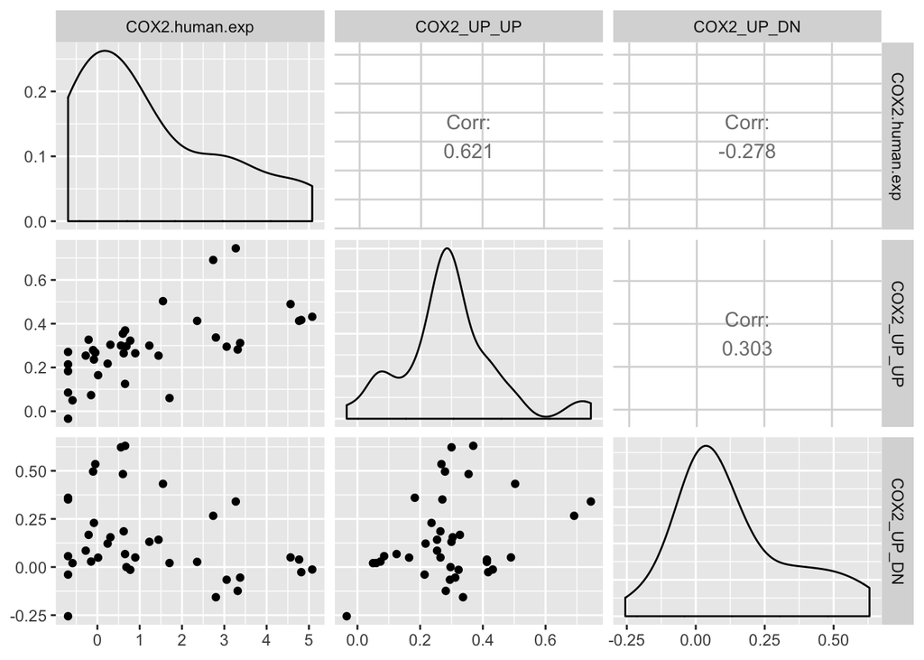

```r
x <- cbind(rnaseq$meta,COX2.human.exp,t(y))
x[,mouse.frac:=mouse.library.size/(human.library.size+mouse.library.size)]

ggpairs(x,columns = c("COX2.human.exp","COX2_UP_UP","COX2_UP_DN"))
```

```r
summary(x[,lm(COX2.human.exp ~ merged.lanes + mouse.frac)])
```

```
##
## Call:
## lm(formula = COX2.human.exp ~ merged.lanes + mouse.frac)
##
## Residuals:
##     Min      1Q  Median      3Q     Max
## -2.3750 -1.3126 -0.4372  1.3766  3.6353
##
## Coefficients:
##              Estimate Std. Error t value Pr(>|t|)
## (Intercept)    1.4808     0.7805   1.897   0.0661 .
## merged.lanes  -0.1968     0.2440  -0.806   0.4255
## mouse.frac     3.0220     5.5649   0.543   0.5905
## ---
## Signif. codes:  0 '***' 0.001 '**' 0.01 '*' 0.05 '.' 0.1 ' ' 1
##
## Residual standard error: 1.753 on 35 degrees of freedom
## Multiple R-squared:  0.04877,    Adjusted R-squared:  -0.005582
## F-statistic: 0.8973 on 2 and 35 DF,  p-value: 0.4168
```

```r
summary(x[,lm(COX2.human.exp ~ COX2_UP_UP)])
```

```
##
## Call:
## lm(formula = COX2.human.exp ~ COX2_UP_UP)
##
## Residuals:
##     Min      1Q  Median      3Q     Max
## -1.7820 -1.1081 -0.4498  0.5493  2.8776
##
## Coefficients:
##             Estimate Std. Error t value Pr(>|t|)
## (Intercept)  -0.7838     0.4820  -1.626    0.113
## COX2_UP_UP    6.9126     1.4543   4.753 3.19e-05 ***
## ---
## Signif. codes:  0 '***' 0.001 '**' 0.01 '*' 0.05 '.' 0.1 ' ' 1
##
## Residual standard error: 1.389 on 36 degrees of freedom
## Multiple R-squared:  0.3856, Adjusted R-squared:  0.3685
## F-statistic: 22.59 on 1 and 36 DF,  p-value: 3.187e-05
```

```r
summary(x[,lm(COX2.human.exp ~ COX2_UP_DN)])
```

```
##
## Call:
## lm(formula = COX2.human.exp ~ COX2_UP_DN)
##
## Residuals:
##     Min      1Q  Median      3Q     Max
## -2.8246 -1.3257 -0.4657  0.9424  3.4904
##
## Coefficients:
##             Estimate Std. Error t value Pr(>|t|)
## (Intercept)   1.5592     0.3313   4.706 3.67e-05 ***
## COX2_UP_DN   -2.2400     1.2891  -1.738   0.0908 .
## ---
## Signif. codes:  0 '***' 0.001 '**' 0.01 '*' 0.05 '.' 0.1 ' ' 1
##
## Residual standard error: 1.703 on 36 degrees of freedom
## Multiple R-squared:  0.07738,    Adjusted R-squared:  0.05175
## F-statistic: 3.019 on 1 and 36 DF,  p-value: 0.09083
```

COX2.human exp is found to positively correlate to the pathway score of COX2_UP_UP within the human reads.

# COX2 Signatures w.r.t mouse reads

## All PDXs

```r
firstup <- function(x){
  x <- tolower(x)
  substr(x, 1, 1) <- toupper(substr(x, 1, 1))
  return(x)
}
PoI <- list(
  "COX2_UP_UP" = "IL6 IL1B IL1A CXCL1 CXCL2 CSF3 CCL2 Ptgs2 Vegfa",
  "COX2_UP_DN" = "IL12B CXCL9 CXCL10 CXCL11 TBX21 CCL5 IFNG GZMB PRF1 IL12A STAT1 IFIT1 IFIT2"
)
PoI <- sapply(PoI, strsplit, split=" ")
PoI <- lapply(PoI, function(p) sapply(p,firstup))
PoI <- lapply(PoI, function(x) data.table(biomaRt::select(org.Mm.eg.db,keys=x,keytype = "SYMBOL",columns = c("ENSEMBL","ENTREZID","SYMBOL"))))
x <- norm.count.matrix(rnaseq$human[rowSums(rnaseq$human)!=0,])
i <- which(rownames(x) == "ENSG00000073756")
COX2.human.exp <- x[i,]

y <- norm.count.matrix(rnaseq$mouse[rowSums(rnaseq$mouse)!=0,])
y <- gsva(y,lapply(PoI,"[[","ENSEMBL"),method="ssgsea")
```

```
## Estimating ssGSEA scores for 2 gene sets.
##
##
```

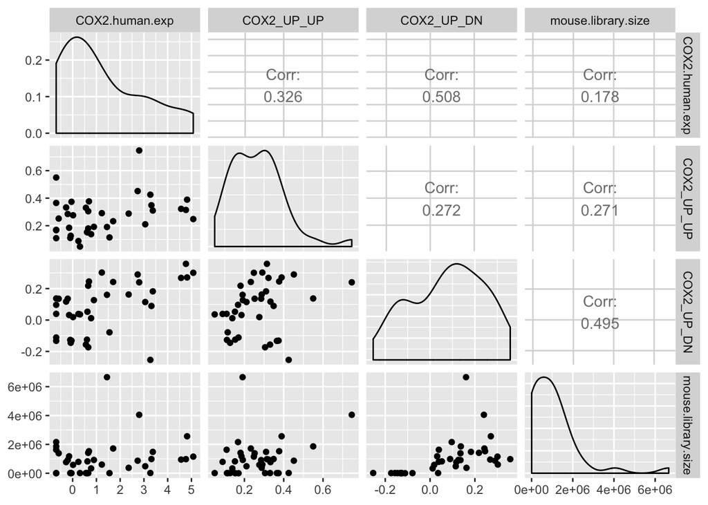

```r
x <- cbind(rnaseq$meta,COX2.human.exp,t(y))
x[,mouse.frac:=mouse.library.size/(human.library.size+mouse.library.size)]

ggpairs(x,columns = c("COX2.human.exp","COX2_UP_UP","COX2_UP_DN","mouse.library.size"))
```

```r
summary(x[,lm(COX2.human.exp ~ merged.lanes + mouse.frac + log(mouse.library.size))])
```

```
##
## Call:
## lm(formula = COX2.human.exp ~ merged.lanes + mouse.frac + log(mouse.library.size))
##
## Residuals:
##     Min      1Q  Median      3Q     Max
## -2.3177 -1.2310 -0.3107  1.1507  3.3466
##
## Coefficients:
##                         Estimate Std. Error t value Pr(>|t|)
## (Intercept)             -1.78761    2.62382  -0.681    0.500
## merged.lanes            -0.08796    0.25565  -0.344    0.733
## mouse.frac              -3.66550    7.52881  -0.487    0.629
## log(mouse.library.size)  0.27222    0.20884   1.303    0.201
##
## Residual standard error: 1.736 on 34 degrees of freedom
## Multiple R-squared:  0.09405,    Adjusted R-squared:  0.01411
## F-statistic: 1.177 on 3 and 34 DF,  p-value: 0.3331
```

```r
summary(x[,lm(COX2_UP_UP ~ COX2.human.exp + merged.lanes + mouse.frac + log(mouse.library.size))])
```

```
##
## Call:
## lm(formula = COX2_UP_UP ~ COX2.human.exp + merged.lanes + mouse.frac +
##     log(mouse.library.size))
##
## Residuals:
##      Min       1Q   Median       3Q      Max
## -0.17452 -0.09287 -0.03298  0.08185  0.38217
##
## Coefficients:
##                          Estimate Std. Error t value Pr(>|t|)
## (Intercept)              0.300261   0.202619   1.482    0.148
## COX2.human.exp           0.021775   0.013154   1.655    0.107
## merged.lanes            -0.019099   0.019643  -0.972    0.338
## mouse.frac               0.367808   0.579479   0.635    0.530
## log(mouse.library.size) -0.003263   0.016414  -0.199    0.844
##
## Residual standard error: 0.1332 on 33 degrees of freedom
## Multiple R-squared:  0.1711, Adjusted R-squared:  0.07058
## F-statistic: 1.702 on 4 and 33 DF,  p-value: 0.173
```

```r
summary(x[,lm(COX2_UP_DN ~ COX2.human.exp + merged.lanes + mouse.frac + log(mouse.library.size))])
```

```
##
## Call:
## lm(formula = COX2_UP_DN ~ COX2.human.exp + merged.lanes + mouse.frac +
##     log(mouse.library.size))
##
## Residuals:
##       Min        1Q    Median        3Q       Max
## -0.240970 -0.051501  0.009989  0.030593  0.165814
##
## Coefficients:
##                           Estimate Std. Error t value Pr(>|t|)
## (Intercept)             -0.7247100  0.1255245  -5.773 1.88e-06 ***
## COX2.human.exp           0.0262137  0.0081491   3.217   0.0029 **
## merged.lanes             0.0005652  0.0121691   0.046   0.9632
## mouse.frac              -0.5111609  0.3589923  -1.424   0.1639
## log(mouse.library.size)  0.0635001  0.0101684   6.245 4.70e-07 ***
## ---
## Signif. codes:  0 '***' 0.001 '**' 0.01 '*' 0.05 '.' 0.1 ' ' 1
##
## Residual standard error: 0.08249 on 33 degrees of freedom
## Multiple R-squared:  0.7669, Adjusted R-squared:  0.7386
## F-statistic: 27.14 on 4 and 33 DF,  p-value: 5.017e-10
```

We find that the pathway COX2_UP_DN within the mouse compoenent is heavily correlated to the mouse.library size. However, our cohort contains samples with as few mouse reads as 10s of thousands. Conditioning on this however, we find that COX2.human exp is found to positively correlated to the pathway score of COX2_UP_DN within the mouse reads. This is the opposite of what is expected.

## 1E5 min. mouse reads

```r
firstup <- function(x){
  x <- tolower(x)
  substr(x, 1, 1) <- toupper(substr(x, 1, 1))
  return(x)
}
PoI <- list(
  "COX2_UP_UP" = "IL6 IL1B IL1A CXCL1 CXCL2 CSF3 CCL2 Ptgs2 Vegfa",
  "COX2_UP_DN" = "IL12B CXCL9 CXCL10 CXCL11 TBX21 CCL5 IFNG GZMB PRF1 IL12A STAT1 IFIT1 IFIT2"
)
PoI <- sapply(PoI, strsplit, split=" ")
PoI <- lapply(PoI, function(p) sapply(p,firstup))
PoI <- lapply(PoI, function(x) data.table(biomaRt::select(org.Mm.eg.db,keys=x,keytype = "SYMBOL",columns = c("ENSEMBL","ENTREZID","SYMBOL"))))
j <- rnaseq$meta[,mouse.library.size>1E5]

x <- norm.count.matrix(rnaseq$human[rowSums(rnaseq$human)!=0,j])
i <- which(rownames(x) == "ENSG00000073756")
COX2.human.exp <- x[i,]

y <- norm.count.matrix(rnaseq$mouse[rowSums(rnaseq$mouse)!=0,j])
y <- gsva(y,lapply(PoI,"[[","ENSEMBL"),method="ssgsea")
```

```
## Estimating ssGSEA scores for 2 gene sets.
##
##
```

```r
x <- cbind(rnaseq$meta,COX2.human.exp,t(y))
```

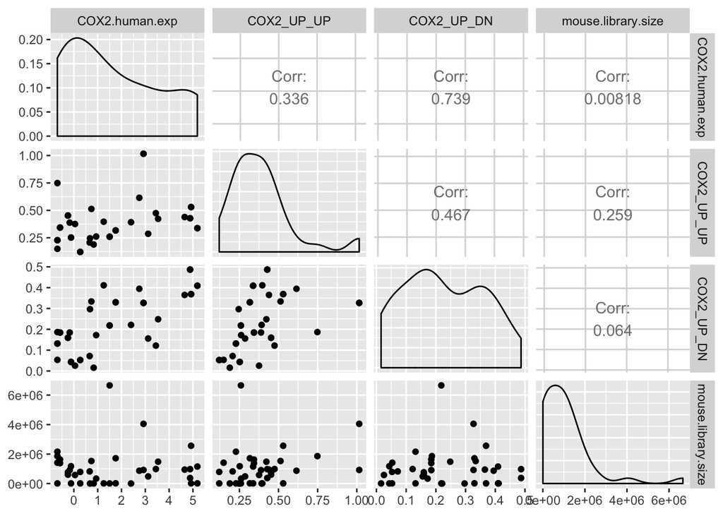

```r
x[,mouse.frac:=mouse.library.size/(human.library.size+mouse.library.size)]

ggpairs(x,columns = c("COX2.human.exp","COX2_UP_UP","COX2_UP_DN","mouse.library.size"))
```

```r
summary(x[,lm(COX2.human.exp ~ merged.lanes + mouse.frac + log(mouse.library.size))])
```

```
##
## Call:
## lm(formula = COX2.human.exp ~ merged.lanes + mouse.frac + log(mouse.library.size))
##
## Residuals:
##     Min      1Q  Median      3Q     Max
## -2.3611 -1.7986 -0.5895  1.4049  3.6175
##
## Coefficients:
##                         Estimate Std. Error t value Pr(>|t|)
## (Intercept)              1.73171    3.16626   0.547    0.588
## merged.lanes            -0.07593    0.30851  -0.246    0.807
## mouse.frac              -1.73833    9.08530  -0.191    0.849
## log(mouse.library.size)  0.01496    0.25202   0.059    0.953
##
## Residual standard error: 2.095 on 34 degrees of freedom
## Multiple R-squared:  0.002605,   Adjusted R-squared:  -0.0854
## F-statistic: 0.02959 on 3 and 34 DF,  p-value: 0.993
```

```r
summary(x[,lm(COX2_UP_UP ~ COX2.human.exp + merged.lanes + mouse.frac + log(mouse.library.size))])
```

```
##
## Call:
## lm(formula = COX2_UP_UP ~ COX2.human.exp + merged.lanes + mouse.frac +
##     log(mouse.library.size))
##
## Residuals:
##      Min       1Q   Median       3Q      Max
## -0.27356 -0.10838 -0.03751  0.07003  0.50431
##
## Coefficients:
##                         Estimate Std. Error t value Pr(>|t|)
## (Intercept)             -0.11092    0.28336  -0.391   0.6980
## COX2.human.exp           0.03429    0.01528   2.244   0.0317 *
## merged.lanes             0.02498    0.02751   0.908   0.3706
## mouse.frac               0.39888    0.80995   0.492   0.6256
## log(mouse.library.size)  0.02896    0.02246   1.289   0.2062
## ---
## Signif. codes:  0 '***' 0.001 '**' 0.01 '*' 0.05 '.' 0.1 ' ' 1
##
## Residual standard error: 0.1867 on 33 degrees of freedom
## Multiple R-squared:  0.2372, Adjusted R-squared:  0.1447
## F-statistic: 2.565 on 4 and 33 DF,  p-value: 0.05642
```

```r
summary(x[,lm(COX2_UP_DN ~ COX2.human.exp + merged.lanes + mouse.frac + log(mouse.library.size))])
```

```
##
## Call:
## lm(formula = COX2_UP_DN ~ COX2.human.exp + merged.lanes + mouse.frac +
##     log(mouse.library.size))
##
## Residuals:
##       Min        1Q    Median        3Q       Max
## -0.188079 -0.080797  0.001586  0.071722  0.221905
##
## Coefficients:
##                         Estimate Std. Error t value Pr(>|t|)
## (Intercept)             0.071653   0.147587   0.485    0.631
## COX2.human.exp          0.050907   0.007959   6.396 3.02e-07 ***
## merged.lanes            0.011398   0.014330   0.795    0.432
## mouse.frac              0.120045   0.421865   0.285    0.778
## log(mouse.library.size) 0.003289   0.011696   0.281    0.780
## ---
## Signif. codes:  0 '***' 0.001 '**' 0.01 '*' 0.05 '.' 0.1 ' ' 1
##
## Residual standard error: 0.09722 on 33 degrees of freedom
## Multiple R-squared:  0.5557, Adjusted R-squared:  0.5019
## F-statistic: 10.32 on 4 and 33 DF,  p-value: 1.561e-05
```

Removing the the samples with low numbers of mouse reads removes the dependency of COX2_UP_DN on the mouse.library.size. However, we still find that COX2.human exp is found to positively correlated to the pathway score of COX2_UP_DN within the mouse reads. Again, this is the opposite of what is expected.